# Getting help from others

Mark Scheuerell

29 January 2027

# Motivation

There is a good chance that you’ve already had to ask someone for help with a question related to some aspect of data science. For example,

- What does this error mean?
- Why can I not reproduce what you’ve done?
- How do I [fill in the blank]?
- Is there an existing package that allows me to [fill in the blank]?

The bad news is that these types of questions may follow you around throughout your career. The good news, however, is that there is a large community of people willing to help you find the solutions you need.

# Minimal, reproducible example

When you get stuck on a problem and need some advice, others will be able to better provide assistance if you include information that

1. they can easily understand, and
2. they can use to reproduce the problem.

This process is variously referred to as creating a

- minimal, **repr**oducible **ex**ample (**reprex**)
- **m**inimal, **c**omplete and **v**erifiable **e**xample (**mcve**)
- **m**inimal, **w**orkable **e**xample (**mwe**)

The bottom line is that you should

- use the least amount of code possible to produce the problem (minimal)
- provide *everything* (code, data) someone would need to reproduce your problem (complete)
- verify that the code you’re about to share reproduces the problem (reproducible)

In addition, you should phrase your question in manner that is polite and free of jargon or other language constructs that might confuse people. The data science community is global, so recognize that someone reading your question might not speak English as a first language. Also consider that others may very well stumble across your question, and hopefully the correct answer, years after it was solved. As such, using plain, descriptive language in the title and body of a post will allow others to find it when searching for answers. For example, [this problem](https://stackoverflow.com/questions/36634641/formatting-table-headings-in-rmarkdown) I posted on Stack Overflow in 2016 has since received over 3000 views!

## Minimal

There tends to be a strong negative correlation between the length of your code and the likelihood that someone will 1) read all the way through it, and 2) actually be able to solve your problem. Therefore, you should consider the following points:

- Consider creating a new script that includes *only those elements germane to the problem*;
- Remove extraneous information that doesn’t influence the problematic code;
- Use simple, descriptive names for parameters, variables, and functions;
- Include meaningful comments in your code to help others understand what you’re trying to accomplish;
- Take advantage of your IDE’s options to create nicely formatted code.

The following commands in **RStudio** can be helpful for formatting code:

- *indent lines*: `command + I` on a Mac or `ctrl + I` in Windows
- *format code*: `command + shift + A` on a Mac or `ctrl + shift + A` in Windows

## Complete

It’s important to include **all** of the information necessary to reproduce the problem *within the question itself*. Don’t put other people in a position where their first response to you is a request for more information. In addition, please consider the following advice:

- If there are data involved, include a *small subset of the data* along with any necessary code;
- Break your problem down into small code blocks and include a description of each block’s purpose;
- It’s OK to include an image or figure in your question, but
- **Do not** use images of code; rather, copy/paste the actual code so others don’t have to re-type anything;
- Include information or links to other problems/solutions that you’ve tried or are referencing.

## Reproducible

In order to help you, other people will need to verify that they can indeed reproduce the problem you’re having. Phrases like “Help!”, “This won’t work!”, or “Why does this happen?” don’t offer much information. Instead, use descriptive language that gets to the question at hand, including:

- Explain what the *expected result* should be;
- Provide the *exact wording* of any error messages;
- Indicate *which line(s) of code* produce(s) the problem;
- Use a *brief, descriptive summary* of your problem as the title of your question.

You should double-check that your example reproduces the problem. It’s good practice to quit **RStudio** (or other software) and restart it from scratch. If possible, consider testing your example on another computer or operating system.

## Metainfo

In addition to minimal, complete, and reproducible code (and possibly data), you should also include information about your larger work environment. This includes:

- your operating system (Mac, Windows, Linux) and its version;
- versions of your software (**R**, packages)

`sessionInfo()` and `packageVersion("package-name-here")` are helpful functions for getting this information.

# Creating a “reprex”

Creating a reproducible example (“reprex”) can take some work, but so does answering other people’s questions. As Jenny Bryan says, “Help me help you.” Here are some options for helping to create a reprex.

## Using `dput()`

Copying/pasting code is relatively easy, but trying to include any data necessary to create a complete reprex can be tricky. In general, including a `.csv` file or other data format is difficult without pointing someone to an external source, link, etc.

The `dput()` function provides a convenient way of writing all of the information in a data frame in a compact manner.

Here’s an example of using `dput()` on the [Palmer penguins data set](https://github.com/allisonhorst/palmerpenguins). This data set is actually quite large, so we’ll only use the first 10 rows of the data frame.

```r
## load the library
library(palmerpenguins)
## get the data & inspect them
data(package = 'palmerpenguins')
head(penguins)
```

```
## # A tibble: 6 × 8
##   species island    bill_length_mm bill_depth_mm flipper_length_mm body_mass_g
##   <fct>   <fct>              <dbl>         <dbl>             <int>       <int>
## 1 Adelie  Torgersen           39.1          18.7               181        3750
## 2 Adelie  Torgersen           39.5          17.4               186        3800
## 3 Adelie  Torgersen           40.3          18                 195        3250
## 4 Adelie  Torgersen           NA            NA                  NA          NA
## 5 Adelie  Torgersen           36.7          19.3               193        3450
## 6 Adelie  Torgersen           39.3          20.6               190        3650
## # ℹ 2 more variables: sex <fct>, year <int>
```

```r
## write the first 10 rows of data
dput(penguins[1:10,])
```

```
## structure(list(species = structure(c(1L, 1L, 1L, 1L, 1L, 1L,
## 1L, 1L, 1L, 1L), levels = c("Adelie", "Chinstrap", "Gentoo"), class = "factor"),
##     island = structure(c(3L, 3L, 3L, 3L, 3L, 3L, 3L, 3L, 3L,
##     3L), levels = c("Biscoe", "Dream", "Torgersen"), class = "factor"),
##     bill_length_mm = c(39.1, 39.5, 40.3, NA, 36.7, 39.3, 38.9,
##     39.2, 34.1, 42), bill_depth_mm = c(18.7, 17.4, 18, NA, 19.3,
##     20.6, 17.8, 19.6, 18.1, 20.2), flipper_length_mm = c(181L,
##     186L, 195L, NA, 193L, 190L, 181L, 195L, 193L, 190L), body_mass_g = c(3750L,
##     3800L, 3250L, NA, 3450L, 3650L, 3625L, 4675L, 3475L, 4250L
##     ), sex = structure(c(2L, 1L, 1L, NA, 1L, 2L, 1L, 2L, NA,
##     NA), levels = c("female", "male"), class = "factor"), year = c(2007L,
##     2007L, 2007L, 2007L, 2007L, 2007L, 2007L, 2007L, 2007L, 2007L
##     )), row.names = c(NA, -10L), class = c("tbl_df", "tbl", "data.frame"
## ))
```

The output from `dput()` may look a bit strange, but it’s **R**’s way of storing the information contained in a data frame.

You can copy/paste the output above into a post with your code and someone could simply assign it to an object and it will render just fine.

```r
## assign output to an object
dat <- structure(list(species = structure(c(1L, 1L, 1L, 1L, 1L, 1L,
1L, 1L, 1L, 1L), .Label = c("Adelie", "Chinstrap", "Gentoo"), class = "factor"),
    island = structure(c(3L, 3L, 3L, 3L, 3L, 3L, 3L, 3L, 3L,
    3L), .Label = c("Biscoe", "Dream", "Torgersen"), class = "factor"),
    bill_length_mm = c(39.1, 39.5, 40.3, NA, 36.7, 39.3, 38.9,
    39.2, 34.1, 42), bill_depth_mm = c(18.7, 17.4, 18, NA, 19.3,
    20.6, 17.8, 19.6, 18.1, 20.2), flipper_length_mm = c(181L,
    186L, 195L, NA, 193L, 190L, 181L, 195L, 193L, 190L), body_mass_g = c(3750L,
    3800L, 3250L, NA, 3450L, 3650L, 3625L, 4675L, 3475L, 4250L
    ), sex = structure(c(2L, 1L, 1L, NA, 1L, 2L, 1L, 2L, NA,
    NA), .Label = c("female", "male"), class = "factor"), year = c(2007L,
    2007L, 2007L, 2007L, 2007L, 2007L, 2007L, 2007L, 2007L, 2007L
    )), row.names = c(NA, -10L), class = c("tbl_df", "tbl", "data.frame"
))

## inspect the object
dat
```

```
## # A tibble: 10 × 8
##    species island    bill_length_mm bill_depth_mm flipper_length_mm body_mass_g
##    <fct>   <fct>              <dbl>         <dbl>             <int>       <int>
##  1 Adelie  Torgersen           39.1          18.7               181        3750
##  2 Adelie  Torgersen           39.5          17.4               186        3800
##  3 Adelie  Torgersen           40.3          18                 195        3250
##  4 Adelie  Torgersen           NA            NA                  NA          NA
##  5 Adelie  Torgersen           36.7          19.3               193        3450
##  6 Adelie  Torgersen           39.3          20.6               190        3650
##  7 Adelie  Torgersen           38.9          17.8               181        3625
##  8 Adelie  Torgersen           39.2          19.6               195        4675
##  9 Adelie  Torgersen           34.1          18.1               193        3475
## 10 Adelie  Torgersen           42            20.2               190        4250
## # ℹ 2 more variables: sex <fct>, year <int>
```

## The `{reprex}` package

The process of creating a reprex can also introduce unintended mistakes in your code when copying/pasting or retyping. As an instructor at UBC, Jenny Bryan found herself responding to hundreds of issues and questions per semester, so she (and others) created the [`{reprex}`](https://reprex.tidyverse.org/) package.

### `{reprex}` from the command line

Begin by loading the `reprex` package.

```r
library(reprex)
```

Select the code you’re interested in and copy it to the clipboard.

```r
a <- 1
b <- 0
a / b
```

Type `reprex()` at the **R** command prompt. It will think for a moment and then respond with a message about the reprex output.

```r
> reprex()
✖ Install the styler package in order to use `style = TRUE`.
ℹ Rendering reprex...
✔ Reprex output is on the clipboard.
```

If you’re using **RStudio**, you’ll see a preview of your rendered reprex in the **Viewer** pane.

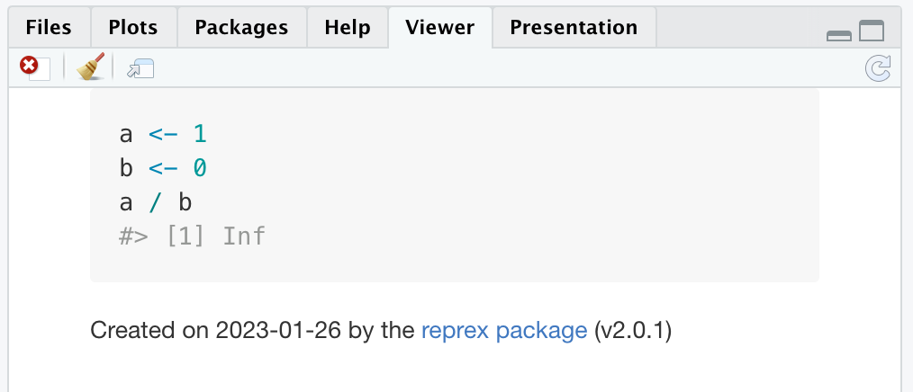

Your code, its result, and some additional information about the date and `reprex` version are all now sitting on your clipboard and available for pasting somewhere for help (see below).

In the background, `reprex` produces this chunk of code, which will render nicely when pasted into a markdown document:

````
```{r}
a <- 1
b <- 0
a / b
#> [1] Inf
```
````

There are a number of additional options you can pass to `reprex()` that will format the output for a particular forum for help (e.g., `venue = gh` for GitHub) or to also include the session information (e.g., `session_info = TRUE`).

### `{reprex}` in RStudio

`{reprex}` is also designed to work seamlessly within **RStudio** and will do most of the work for you. To do so, you can access its functionality via the **Addins** pulldown menu.

Click [here](https://rstudio.github.io/rstudioaddins/) to learn more about **RStudio** addins.

After you’ve loaded the `{reprex}` package, click on the **Addins** pulldown menu in the code pane and type “reprex” in the search bar. Select **Render reprex…** from the menu.

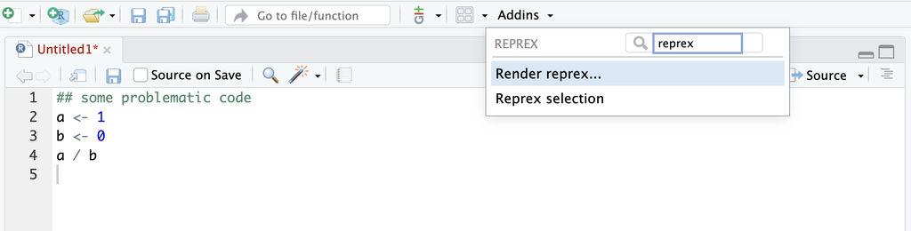

You should see up a popup window with choices about where the code is located, the target venue for help, and whether you want to append the session information.

Make your desired selections and click on the blue **Render** button in the upper right, which will copy all of the information to your clipboard and also display in the **Viewer** pane.

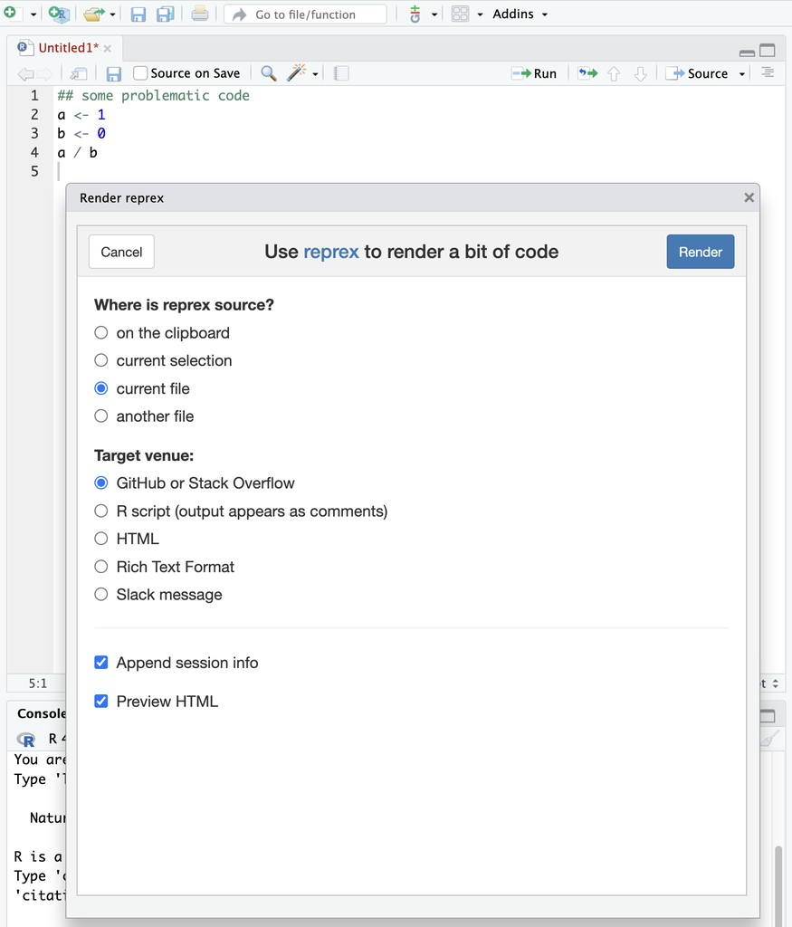

At this point you have several options for seeking answers to your question or problem. The following example shows an option for creating an Issue in GitHub, but there are lots of others (see next section).

Navigate to a GitHub repo (perhaps the one where your coding project lives) and create a new issue with an informative title.

[figure not shown]

In the **Write** window, paste the reprex you created above and add some informative text above it. You may also want to select some labels on the righthand side (e.g., “bug”, “help wanted”).

[figure not shown]

You can click on the **Preview** tab to check the formatting of your reprex.

When you are ready, scroll down and click on the green **Submit new issue** button.

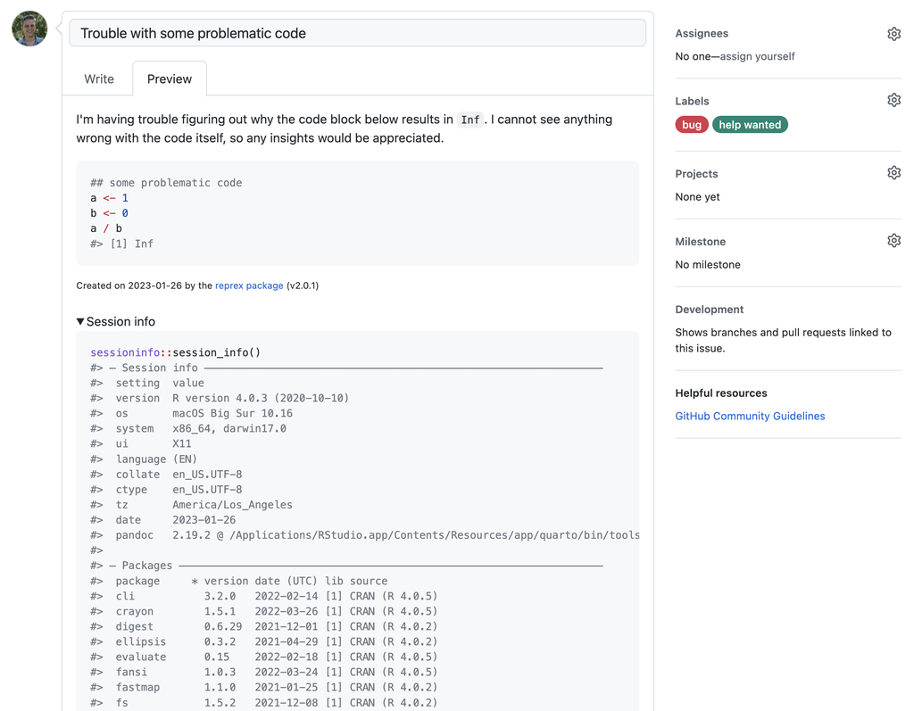

# Where to get help

Now that you know *how* to ask for help, let’s consider some places *where* you can find help. One of the first things I often do is to simply use Google to search for my problem or error message. Sometimes you can find the answer rather quickly, but often you’ll be presented with an array of possible solutions that require you to read through the various questions and corresponding answers that others have posed. In the end, your desire for a quick resolution can be countered by the time you’ll spend combing through lots of extraneous information. Therefore, you might want to consider these other options.

## AI

AI is a hot topic these days, and there are a number of AI tools that can help you with coding problems. For example, ChatGPT or Claude can be used to generate code snippets, explain error messages, and provide guidance on best practices. However, it’s important to remember that AI is not infallible and may provide incorrect or incomplete information. Always verify the information you receive from AI tools and use them as a supplement to your own knowledge and research.

## Colleagues

Your friends, colleagues, advisor, and committee members can be a great resource for help. Asking people you know can be much less intimidating than engaging with anonymous strangers. Turning to your officemate and asking them for help can be quick and also gratifying for them if they were able to help. Many lab groups have Slack channels for `#coding` or `#programming`, so consider asking there as well.

## RStudio community

The **RStudio** community provides a [nice forum](https://community.rstudio.com/) for people to ask questions specific to **R**, **RStudio**, and various packages (e.g., the “tidyverse”). The people tend to be compassionate and caring—they genuinely want to help rather than simply espouse their knowledge to whomever will listen.

## Social media

In general, social media is a great source of information on **R** and data science. Although it’s difficult to squeeze a reprex into limited character spaces, you can share links to locations where you’ve posted a reprex (e.g., a [GitHub Gist](https://gist.github.com/)). Also consider checking in on the **#rstats** hashtag or including it in a post asking for help.

## Stack Overflow

If you tried searching for an answer to your problem, there’s a good chance you’ve come across some posts on [Stack Overflow](https://stackoverflow.com/), or “SO” as it’s often referred. SO has keywords or tags that people can use to highlight the software or packages they’re using (e.g., “R”, “dplyr”), which allows you to filter results. SO also has a reputation of being an intimidating forum with often snarky comments on posts. However, if you’ve taken the time to create a good reprex, you shouldn’t encounter any problems.

## GitHub

### Issues

As you start working more with teams on projects that are hosted on GitHub, you will invariably run into bugs, problems, errors, etc that you can’t resolve yourself. Creating an issue that includes a reprex and description of the problem is a great way to solicit help, as well as maintain a record for future reference.

In some cases, you may encounter a problem or discover a bug in a particular **R** package. Although [CRAN](https://cran.r-project.org/) is the primary location for hosting pacakges, many developers also maintain GitHub repos for their packages. These developers typically ask people to file an issue with the stipulation that you be polite and follow some general guidelines. Issues along the lines of “this doesn’t work” or “why won’t you update this” have a pretty good chance of being ignored. Very few people are paid to develop and maintain packages, so treat their time and effort with respect.

### Gists

GitHub provides another means to share code snippets via so-called [*gists*](https://docs.github.com/en/get-started/writing-on-github/editing-and-sharing-content-with-gists/creating-gists). When you create a gist, you can copy/paste the URL for its location into an issue, direct message, email, etc to share with others. You can also access all of the gists you create via your own [gist home page](https://gist.github.com/). Gists can be set to private or public, the latter of which are discoverable via web searches. Gists are also repos, which means you can view commit histories and for or clone them.

Here are some instructions for creating a new gist.

Navigate to the gist home page [here](https://gist.github.com/).

[figure not shown]

Click the ‘**+**’ sign in the upper right to create a new gist.

[figure not shown]

Give your gist a *short but informative* title.

[figure not shown]

Give your gist a short file name.

Including the `.md` suffix for a Markdown document will bring up some additional editing info.

[figure not shown]

Include some background information, as neccessary, and anything else you think would be helpful.

[figure not shown]

You click on the **Preview** tab to see how your document will look when saved.

[figure not shown]

- Click on the down arrow next to the green **Create [option] gist** button to change options from private to public.
- Click on the **Create [option] gist** button.

[figure not shown]

You now have a gist that can be accessed via your account or shared with others.

[figure not shown]